# PLINSTAT lab 2 exercise

In this exercise, we will be recapping data manipulation and visualisation skills and check normality to prepare for inferential tests. **We’ll also learn more functions to manipulate your dataset, which we don’t have time to cover in the lab.**

## Dataset

This exercise will use a R built in dataset called USJudgeRatings.

The data contains average ratings of 43 different judges’ abilities by lawyers in the US. Each row is a lawyer (i.e., the rater), and each column is a measure. You can type “USJudgeRatings” into the Help pane and read more about it. For example,

- The first column **CONT** gives the mean number of contacts each judge has had with the lawyers doing the ratings.
- The following columns give mean ratings out of 10 by the lawyers of the judge’s abilities in different areas of their job.
- The final column **RTEN** gives the lawyers’ judgement about whether the judge is worthy of retention.

We will be recapping data manipulation and visualisation skills and check normality to prepare for inferential tests.

## 1. Set-up

Q1. Set working directory to your folder containing the files. Load in the tidyverse and `USJudgeRatings` dataset, saving it as `data`

HINT: `setwd()`, `library()`, `read.csv()`

```r
setwd("D:/03_PhD_UCL/UCL demonstratorship/PLINSTAT/2022 May-June/week2")

library(tidyverse)

data <- read.csv("USJudgeRatings.csv")
```

Q2. Is the dataframe in WIDE or LONG format?

```r
# type your answer here: wide
```

## 2. Data manipulation

Q3. First remove the column reflecting ‘Worthy of retention’ (i.e., RTEN) as we are not interested in that variable (save the new object as `data`)

HINT: Use `select(dataframe_name, <column names>)` to select the columns to keep. For exmaple, `select(data, c("CONT", "INTG", "DMNR"))`. Alternatively, you can drop columns that you don’t need any more by using a minus symbol `-`. For example, to drop the INTG column, you can use `select(data, -INTG)`.

```r
data <- select(data, -RTEN)
```

Q4. Next create a new column `ID` so that we can identify the judges anonymously. The first row has ID of 1, the second has ID of 2, etc (recall that a row is a lawyer who rated the judge so ID is the participant ID).

HINT: Use `mutate(column_name = ...)` to create a new column or edit an existing column.

```r
data <- data %>% mutate(ID=1:43)
```

Q5. Next we want to convert the table to a long format with three columns: `ID`, `Variable` and `Score`: save this as object data2

HINT: Use `gather()`

```r
data2 <- data %>% gather(key='Variable', value='Score', CONT:PHYS)
```

## 2. Descriptive Statistics

Q6. Now we can summarise the data. Make a table of mean, SD, SE and 95% confidence intervals for each variable and save it as `summary`.

HINT: Use `group_by()`, `summarise()`

```r
summary <- data2 %>% group_by(Variable) %>%
  summarise(mean = mean(Score),
            sd = sd(Score),
            se = sd/sqrt(n()),
            ci_lower = mean - 1.96*se,
            ci_upper = mean + 1.96*se)
```

## 3. Further manipulation

Q7. Create a new dataframe (`data3`) that comprises `ID` and `Total`. Total is the **sum score** of all variables except number of contacts with judge (i.e., CONT).

HINT: Use `filter()`, `group_by()` and `summarise()`

```r
data3 <- data2 %>%
  filter(Variable != 'CONT') %>%
  group_by(ID) %>%
  summarise(Total = sum(Score))
```

Q8. Now we will integrate the total (in `data3`) with all other measures (in `data`) and save it as `data4`.

HINT: Use `inner_join()`

```r
data4 <- data3 %>% inner_join(data, by='ID')
```

Now we have ID, Number of contacts of lawyer with judge (CONT), 10 measures of the judge (from INTG to PHYS), and a total score of all measures. Take a look at first 6 rows of the dataframe.

HINT: Use `head()`

```r
head(data4)
```

```
# A tibble: 6 × 13
     ID Total  CONT  INTG  DMNR  DILG  CFMG  DECI  PREP  FAMI  ORAL  WRIT  PHYS
  <int> <dbl> <dbl> <dbl> <dbl> <dbl> <dbl> <dbl> <dbl> <dbl> <dbl> <dbl> <dbl>
1     1  74     5.7   7.9   7.7   7.3   7.1   7.4   7.1   7.1   7.1   7     8.3
2     2  82.3   6.8   8.9   8.8   8.5   7.8   8.1   8     8     7.8   7.9   8.5
3     3  76.4   7.2   8.1   7.8   7.8   7.5   7.6   7.5   7.5   7.3   7.4   7.9
4     4  86     6.8   8.8   8.5   8.8   8.3   8.5   8.7   8.7   8.4   8.5   8.8
5     5  56.7   7.3   6.4   4.3   6.5   6     6.2   5.7   5.7   5.1   5.3   5.5
6     6  82.6   6.2   8.8   8.7   8.5   7.9   8     8.1   8     8     8     8.6
```

PS: You can always name the dataframe `data` instead of `data2`, `data3`, `data4` to avoid too many (useless) objects in your environment. However, this would overwrite your original `data` dataframe, so you won’t be able to come back to it. There is a balance between creating new objects and keeping the environment tidy…

## 4. Data visualisation

Q9. Make a graph to help you decide whether the total ratings are normally distributed, check the Skewness and Kurtosis values, and test normality using Shapiro-Wilk test.

HINT: Histogram, `describe()` (from the psych package), `shapiro.test()`

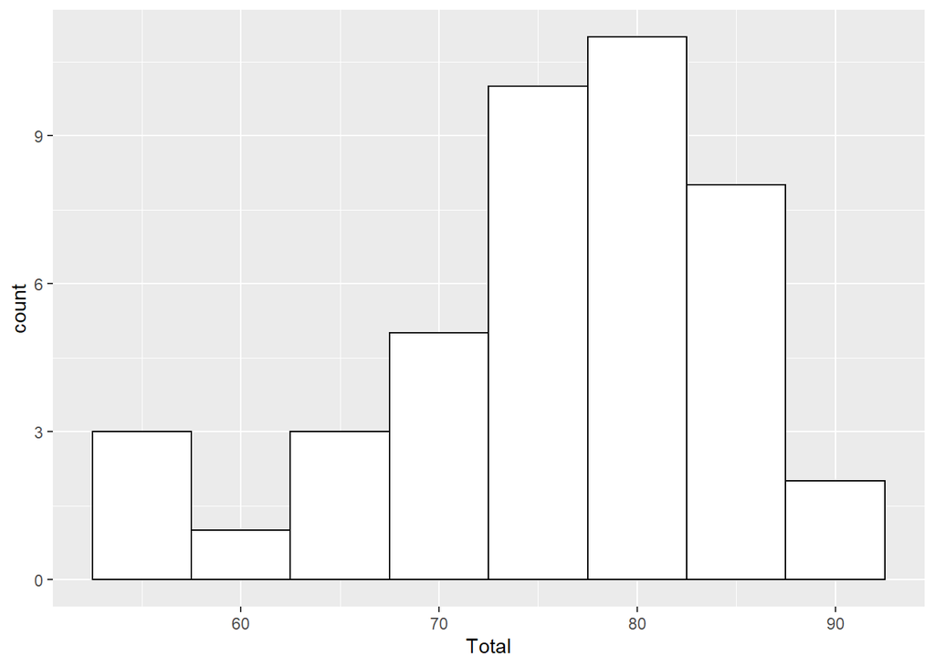

```r
# histogram
ggplot(data4, aes(x = Total)) +
  geom_histogram(binwidth = 5, fill = "white", color = "black")
```

```r
# skewness and kurtosis
library(psych)
describe(data4$Total)
```

```
   vars  n  mean   sd median trimmed  mad  min  max range  skew kurtosis   se
X1    1 43 75.84 8.89   77.4   76.73 7.71 53.5 89.2  35.7 -0.76    -0.07 1.36
```

```r
# skewness = -0.76, kurtosis = -0.07

# shapiro-wilk test
shapiro.test(data4$Total)
```

```
    Shapiro-Wilk normality test

data:  data4$Total
W = 0.93925, p-value = 0.02444
```

```r
# p value = 0.024
```

Is the Shapiro-Wilk test significant? What does it mean?

```r
# type your answer here: It is significant so the Total score is not normally distributed.
```

Q10. Next plot the relationship between number of contacts and total rating (add an estimated regression line).

HINT: scatter plot

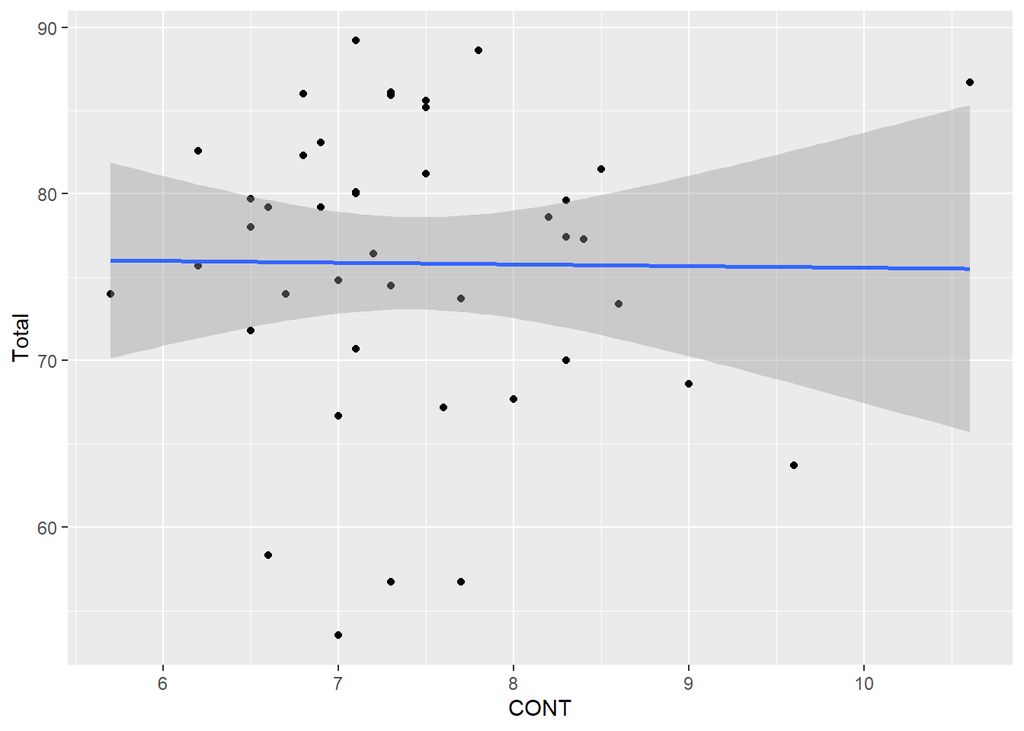

```r
ggplot(data4, aes(x=CONT, y=Total)) +
  geom_point() +
  geom_smooth(method = "lm")
```

Q11. Create a bar plot of Judicial integrity (INTG), Demeanor (DMNR), Diligence (DILG), including mean, SD, and CI.

HINT: Use the `summary` dataframe, filter relevant variables, use `stat = "identity"` in the `geom_bar()` function, add CI with `geom_errorbar()`

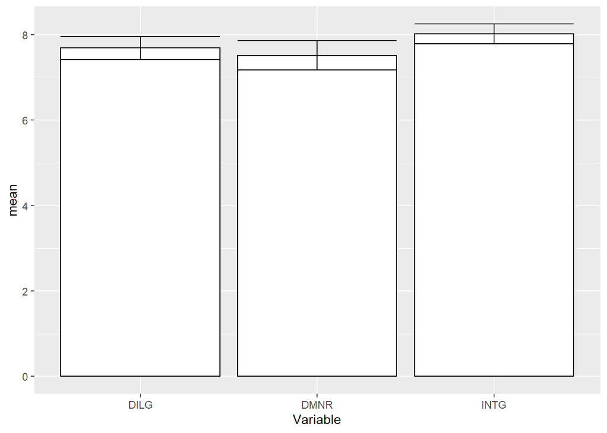

```r
ggplot(filter(summary, Variable %in% c("INTG", "DMNR", "DILG")), aes(x = Variable, y = mean)) +
  geom_bar(stat = "identity", fill = "white", color = "black") +
  geom_errorbar(aes(ymin = ci_lower, ymax = ci_upper))
```